# Chronic pulmonary disorders

# 1 Description of DataSchema variable

The description of harmonised variable is the following:

- Short name: `h_cpd`
- Variable label: `History of chronic pulmonary disorders`
- Variable description: `history of chronic pulmonary disease`
- Domain: `Diseases`
- Value type: `categorical`
- Category coding:

| **Code** | **Category Label** |
| --- | --- |
| 0 | NO chronic pulmonary disease |
| 1 | chronic pulmonary disease |

- Category missings:

| **Code** | **Category Label** |
| --- | --- |
| 991 | CAPI/interviewer error |
| 992 | Impute |
| 993 | Disable to measure |
| 994 | Not attempt/not done |
| 995 | Does not answer |
| 996 | Not applicable |
| 997 | Refuse |
| 998 | Do not know |
| 999 | Missing |

- Short name: `h_cpd_age`
- Variable label: `Age first diagnosed chronic pulmonary disease`
- Variable description: `The age first told had chronic lung disease diagnosis`
- Domain: `Diseases`
- Value type: `Continuous`
- Category missings:

| **Code** | **Category Label** |
| --- | --- |
| 991 | CAPI/interviewer error |
| 992 | Impute |
| 993 | Disable to measure |
| 994 | Not attempt/not done |
| 995 | Does not answer |
| 996 | Not applicable |
| 997 | Refuse |
| 998 | Do not know |
| 999 | Missing |

# 2 Data process

## 2.1 England

### 2.1.1 Wave 1

#### 2.1.1.1 Study-specific variable description

| **Name** | `hedib01` | `hedib02` | `hedib03` | `hedib04` | `hedib05` | `hedib06` | `hedib07` | `hedib08` | `hedib09` | `hedib10` |
| --- | --- | --- | --- | --- | --- | --- | --- | --- | --- | --- |
| **Label** | `Has a doctor ever told you that you [have/have had] any of the conditions in this card?{chronic lung disease ..}` | `Has a doctor ever told you that you [have/have had] any of the conditions in this card?{chronic lung disease ..}` | `Has a doctor ever told you that you [have/have had] any of the conditions in this card?{chronic lung disease ..}` | `Has a doctor ever told you that you [have/have had] any of the conditions in this card?{chronic lung disease ..}` | `Has a doctor ever told you that you [have/have had] any of the conditions in this card?{chronic lung disease ..}` | `Has a doctor ever told you that you [have/have had] any of the conditions in this card?{chronic lung disease ..}` | `Has a doctor ever told you that you [have/have had] any of the conditions in this card?{chronic lung disease ..}` | `Has a doctor ever told you that you [have/have had] any of the conditions in this card?{chronic lung disease ..}` | `Has a doctor ever told you that you [have/have had] any of the conditions in this card?{chronic lung disease ..}` | `Has a doctor ever told you that you [have/have had] any of the conditions in this card?{chronic lung disease ..}` |
| **Table name** | `wave_1_core_data_v3` | `wave_1_core_data_v3` | `wave_1_core_data_v3` | `wave_1_core_data_v3` | `wave_1_core_data_v3` | `wave_1_core_data_v3` | `wave_1_core_data_v3` | `wave_1_core_data_v3` | `wave_1_core_data_v3` | `wave_1_core_data_v3` |
| **Categories** | `1 = Chronic lung disease such as chronic bronchitis or emphysema` `2 = Asthma` `3 = Arthritis (including osteoarthritis , or rheumatism)` `4 = Osteoporosis, sometimes called thin or brittle bones` `5… | `1 = Chronic lung disease such as chronic bronchitis or emphysema` `2 = Asthma` `3 = Arthritis (including osteoarthritis , or rheumatism)` `4 = Osteoporosis, sometimes called thin or brittle bones` `5… | `1 = Chronic lung disease such as chronic bronchitis or emphysema` `2 = Asthma` `3 = Arthritis (including osteoarthritis , or rheumatism)` `4 = Osteoporosis, sometimes called thin or brittle bones` `5… | `1 = Chronic lung disease such as chronic bronchitis or emphysema` `2 = Asthma` `3 = Arthritis (including osteoarthritis , or rheumatism)` `4 = Osteoporosis, sometimes called thin or brittle bones` `5… | `1 = Chronic lung disease such as chronic bronchitis or emphysema` `2 = Asthma` `3 = Arthritis (including osteoarthritis , or rheumatism)` `4 = Osteoporosis, sometimes called thin or brittle bones` `5… | `1 = Chronic lung disease such as chronic bronchitis or emphysema` `2 = Asthma` `3 = Arthritis (including osteoarthritis , or rheumatism)` `4 = Osteoporosis, sometimes called thin or brittle bones` `5… | `1 = Chronic lung disease such as chronic bronchitis or emphysema` `2 = Asthma` `3 = Arthritis (including osteoarthritis , or rheumatism)` `4 = Osteoporosis, sometimes called thin or brittle bones` `5… | `1 = Chronic lung disease such as chronic bronchitis or emphysema` `2 = Asthma` `3 = Arthritis (including osteoarthritis , or rheumatism)` `4 = Osteoporosis, sometimes called thin or brittle bones` `5… | `1 = Chronic lung disease such as chronic bronchitis or emphysema` `2 = Asthma` `3 = Arthritis (including osteoarthritis , or rheumatism)` `4 = Osteoporosis, sometimes called thin or brittle bones` `5… | `1 = Chronic lung disease such as chronic bronchitis or emphysema` `2 = Asthma` `3 = Arthritis (including osteoarthritis , or rheumatism)` `4 = Osteoporosis, sometimes called thin or brittle bones` `5… |
| **Missings** | `-9 = Refusal` `-8 = Don't know` `-1 = Not applicable` | `-9 = Refusal` `-8 = Don't know` `-1 = Not applicable` | `-9 = Refusal` `-8 = Don't know` `-1 = Not applicable` | `-9 = Refusal` `-8 = Don't know` `-1 = Not applicable` | `-9 = Refusal` `-8 = Don't know` `-1 = Not applicable` | `-9 = Refusal` `-8 = Don't know` `-1 = Not applicable` | `-9 = Refusal` `-8 = Don't know` `-1 = Not applicable` | `-9 = Refusal` `-8 = Don't know` `-1 = Not applicable` | `-9 = Refusal` `-8 = Don't know` `-1 = Not applicable` | `-9 = Refusal` `-8 = Don't know` `-1 = Not applicable` |
| **Description** |  |  |  |  |  |  |  |  |  |  |

hedib01

| Sample size | Missing values |
| --- | --- |
| 12099 | 10 |

Category

|  | 1 | 2 | 3 | 4 | 5 | 6 | 7 | 8 | 9 | 96 |
| --- | --- | --- | --- | --- | --- | --- | --- | --- | --- | --- |
| Frequency | 680.00 | 1172.00 | 3042.00 | 247.00 | 421.00 | 33.00 | 426.00 | 9.00 | 21.00 | 6038.0 |
| Percentage | 5.62 | 9.69 | 25.14 | 2.04 | 3.48 | 0.27 | 3.52 | 0.07 | 0.17 | 49.9 |

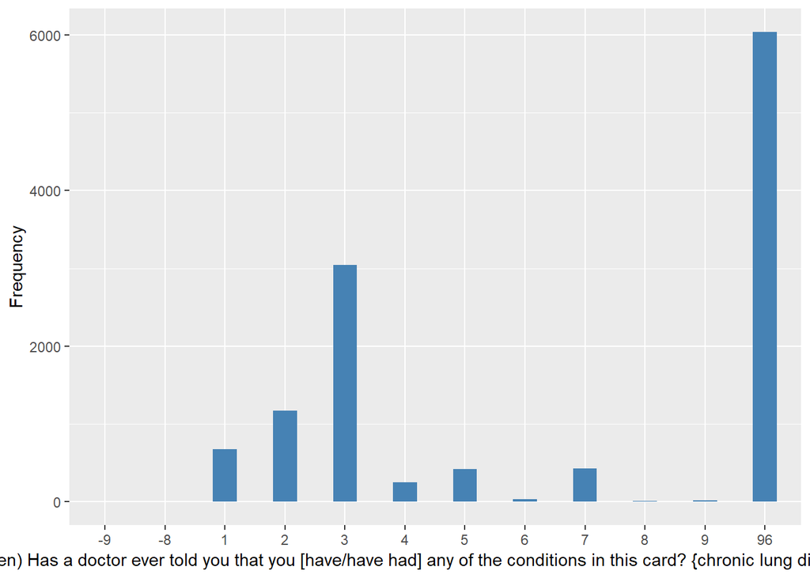

hedib02

| Sample size | Missing values |
| --- | --- |
| 12099 | 10312 |

Category

|  | 1 | 2 | 3 | 4 | 5 | 6 | 7 | 8 | 9 |
| --- | --- | --- | --- | --- | --- | --- | --- | --- | --- |
| Frequency | 72.0 | 239.00 | 641.0 | 237.00 | 231.00 | 18.00 | 319.00 | 2.00 | 28.00 |
| Percentage | 0.6 | 1.98 | 5.3 | 1.96 | 1.91 | 0.15 | 2.64 | 0.02 | 0.23 |

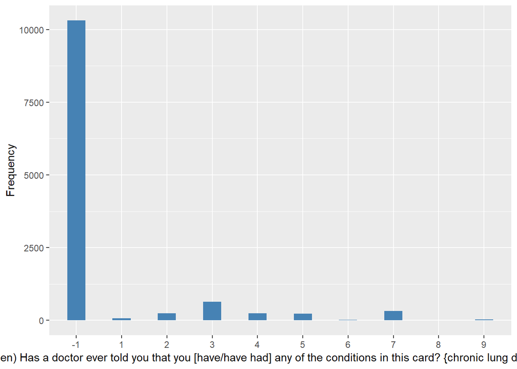

hedib03

| Sample size | Missing values |
| --- | --- |
| 12099 | 11687 |

Category

|  | 1 | 2 | 3 | 4 | 5 | 6 | 7 | 8 | 9 |
| --- | --- | --- | --- | --- | --- | --- | --- | --- | --- |
| Frequency | 10.00 | 4.00 | 126.00 | 70.00 | 62.00 | 4.00 | 122.00 | 2.00 | 12.0 |
| Percentage | 0.08 | 0.03 | 1.04 | 0.58 | 0.51 | 0.03 | 1.01 | 0.02 | 0.1 |

[figure not shown]

hedib04

| Sample size | Missing values |
| --- | --- |
| 12099 | 12028 |

Category

|  | 1 | 2 | 3 | 4 | 5 | 6 | 7 | 9 |
| --- | --- | --- | --- | --- | --- | --- | --- | --- |
| Frequency | 1.00 | 1.00 | 1.00 | 18.00 | 11.00 | 1.00 | 35.00 | 3.00 |
| Percentage | 0.01 | 0.01 | 0.01 | 0.15 | 0.09 | 0.01 | 0.29 | 0.02 |

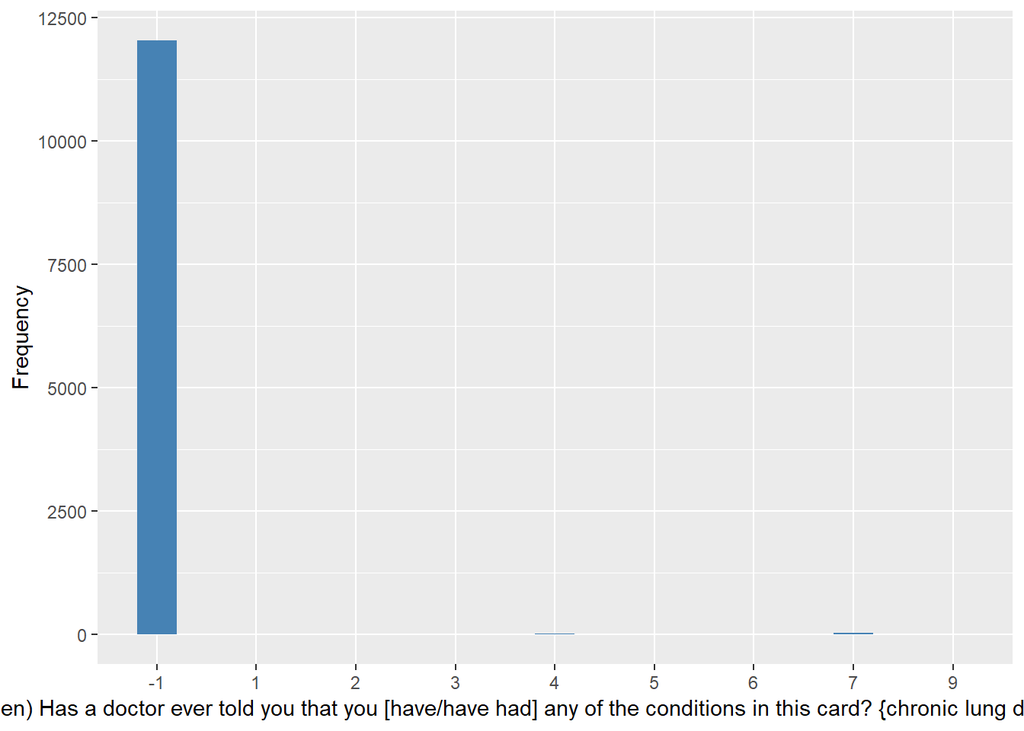

hedib05

| Sample size | Missing values |
| --- | --- |
| 12099 | 12089 |

Category

|  | 2 | 5 | 7 |
| --- | --- | --- | --- |
| Frequency | 1.00 | 2.00 | 7.00 |
| Percentage | 0.01 | 0.02 | 0.06 |

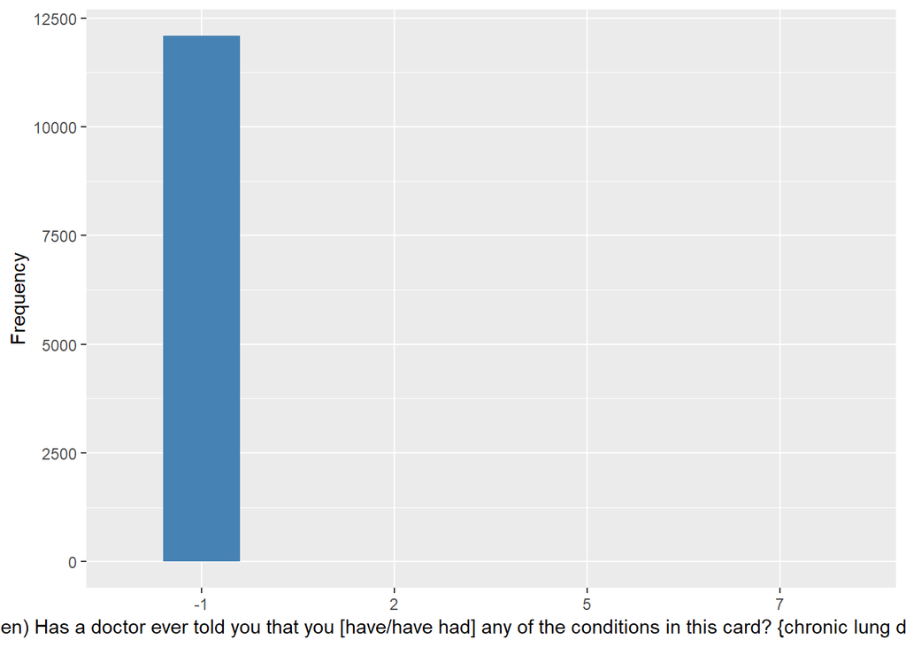

hedib06

| Sample size | Missing values |
| --- | --- |
| 12099 | 12098 |

Category

|  | 8 |
| --- | --- |
| Frequency | 1.00 |
| Percentage | 0.01 |

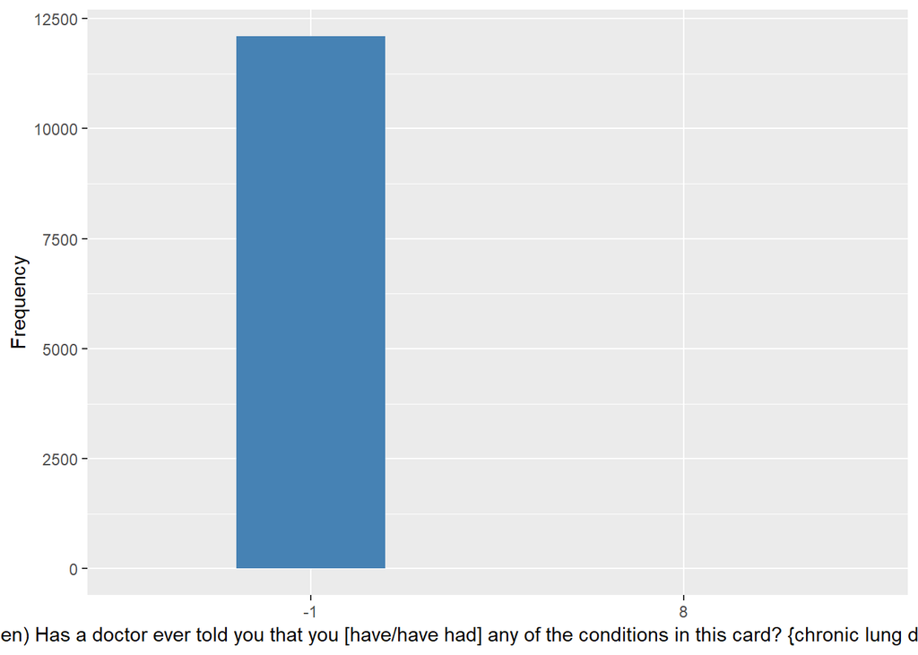

hedib07

| Sample size | Missing values |
| --- | --- |
| 12099 | 12099 |

hedib08

| Sample size | Missing values |
| --- | --- |
| 12099 | 12099 |

hedib09

| Sample size | Missing values |
| --- | --- |
| 12099 | 12099 |

hedib10

| Sample size | Missing values |
| --- | --- |
| 12099 | 12099 |

#### 2.1.1.2 Harmonisation algorithm

To compute `h_cpd` from the study-specific variable it has to be recoded as follows:

- `some hedibX == 1 into 1`
- `-9 into 997`
- `-8 into 998`
- `otherwise into 0`

Age of diagnosis cannot be harmonized.

**R script:**

```r
# Categorical variable harmonization
ELSA_ds_w1 <- tibble(id = ELSA_w1$id)
ELSA_ds_w1$h_cpd <- rep(0, length(ELSA_w1$id))
ELSA_ds_w1$h_cpd[which((ELSA_w1$hedib01 == 1 | ELSA_w1$hedib02 == 1 | ELSA_w1$hedib03 ==
    1 | ELSA_w1$hedib04 == 1 | ELSA_w1$hedib05 == 1 | ELSA_w1$hedib06 == 1 |
    ELSA_w1$hedib07 == 1 | ELSA_w1$hedib08 == 1 | ELSA_w1$hedib09 == 1 | ELSA_w1$hedib10 ==
    1))] <- 1
ELSA_ds_w1$h_cpd[which(ELSA_w1$hedib01 == -9)] <- 997
ELSA_ds_w1$h_cpd[which(ELSA_w1$hedib01 == -8)] <- 998

# Global table
ELSA_ds <- ELSA_ds_w1
ELSA_ds$h_cpd_age <- rep(999, length(ELSA_ds$id))
```

#### 2.1.1.3 Statistics of the new harmonized variable

History of chronic pulmonary disorders

| Sample size | Missing values |
| --- | --- |
| 12099 | 10 |

Category

|  | 0 | 1 |
| --- | --- | --- |
| Frequency | 11326.00 | 763.00 |
| Percentage | 93.61 | 6.31 |

Type of missing

|  | 991 | 992 | 993 | 994 | 995 | 996 | 997 | 998 | 999 | NA |
| --- | --- | --- | --- | --- | --- | --- | --- | --- | --- | --- |
| Frequency | 0 | 0 | 0 | 0 | 0 | 0 | 4.00 | 6.00 | 0 | 0 |
| Percentage | 0 | 0 | 0 | 0 | 0 | 0 | 0.03 | 0.05 | 0 | 0 |

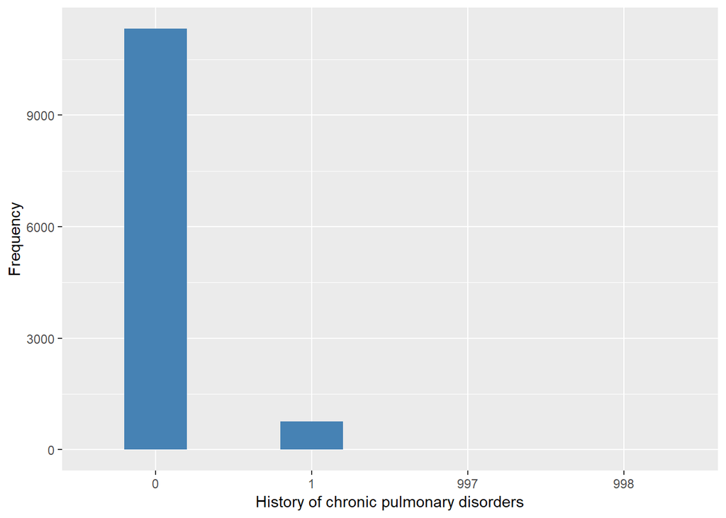

#### 2.1.1.4 Validation

|  | hedibX!=1->0 | hedibX==1->1 | hedibX==-9->997 | hedibX==-8->998 |
| --- | --- | --- | --- | --- |
| BeforeH | 11326 | 763 | 4 | 6 |
| AfterH | 11326 | 763 | 4 | 6 |

### 2.1.2 Wave 2

#### 2.1.2.1 Study-specific variable description

| **Name** | `hedib01` | `hedib02` | `hedib03` | `hedib04` | `ybirth` | `yintw (w1)` | `yintw (w2)` |  |
| --- | --- | --- | --- | --- | --- | --- | --- | --- |
| **Label** | `Diagnosed chronic condition newly reported at W2 (1st mention)` | `Diagnosed chronic condition newly reported at W2 (2nd mention)` | `Diagnosed chronic condition newly reported at W2 (3rd mention)` | `Diagnosed chronic condition newly reported at W2 (4th mention)` | `year of birth` | `year of interview` | `year of interview` |  |
| **Table name** | `wave_2_core_data_v4` | `wave_2_core_data_v4` | `wave_2_core_data_v4` | `wave_2_core_data_v4` | `elsa_w2_hd` | `elsa_w1_hd` | `elsa_w2_hd` |  |
| **Categories** | `1 = Chronic lung disease such as chronic bronchitis or emphysema` `2 = Asthma` `3 = Arthritis (including osteoarthritis , or rheumatism)` `4 = Osteoporosis, sometimes called thin or brittle bones` `5… | `1 = Chronic lung disease such as chronic bronchitis or emphysema` `2 = Asthma` `3 = Arthritis (including osteoarthritis , or rheumatism)` `4 = Osteoporosis, sometimes called thin or brittle bones` `5… | `1 = Chronic lung disease such as chronic bronchitis or emphysema` `2 = Asthma` `3 = Arthritis (including osteoarthritis , or rheumatism)` `4 = Osteoporosis, sometimes called thin or brittle bones` `5… | `1 = Chronic lung disease such as chronic bronchitis or emphysema` `2 = Asthma` `3 = Arthritis (including osteoarthritis , or rheumatism)` `4 = Osteoporosis, sometimes called thin or brittle bones` `5… | `continuous` | `continuous` | `continuous` |  |
| **Missings** | `-9 = Refusal` `-8 = Don't know` `-1 = Not applicable` | `-9 = Refusal` `-8 = Don't know` `-1 = Not applicable` `NA` | `-9 = Refusal` `-8 = Don't know` `-1 = Not applicable` `NA` | `-9 = Refusal` `-8 = Don't know` `-1 = Not applicable` |  |  |  |  |
| **Description** |  |  |  |  |  |  |  |  |

hedib01

| Sample size | Missing values |
| --- | --- |
| 9432 | 6 |

Category

|  | 1 | 2 | 3 | 4 | 5 | 6 | 7 | 8 | 9 | 96 |
| --- | --- | --- | --- | --- | --- | --- | --- | --- | --- | --- |
| Frequency | 143.00 | 128.00 | 574.00 | 183.00 | 175.00 | 18.00 | 193.00 | 11.00 | 33.00 | 7968.00 |
| Percentage | 1.52 | 1.36 | 6.09 | 1.94 | 1.86 | 0.19 | 2.05 | 0.12 | 0.35 | 84.48 |

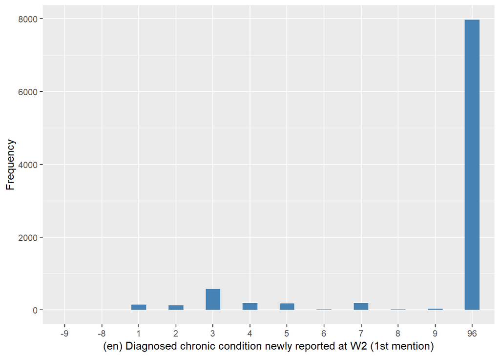

hedib02

| Sample size | Missing values |
| --- | --- |
| 9432 | 9310 |

Category

|  | 1 | 2 | 3 | 4 | 5 | 7 | 9 |
| --- | --- | --- | --- | --- | --- | --- | --- |
| Frequency | 4.00 | 11.00 | 19.0 | 19.0 | 27.00 | 35.00 | 7.00 |
| Percentage | 0.04 | 0.12 | 0.2 | 0.2 | 0.29 | 0.37 | 0.07 |

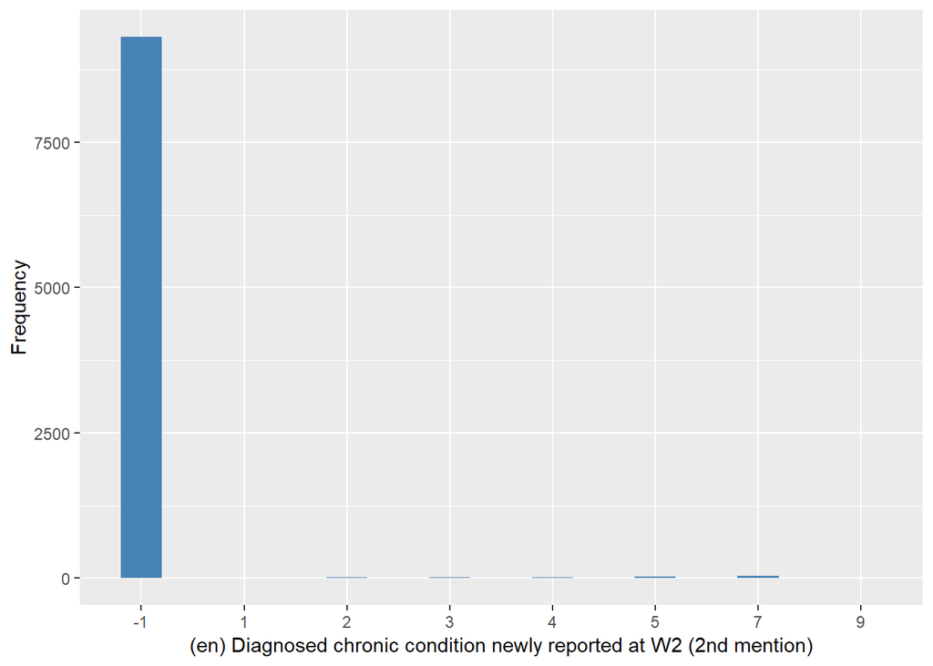

hedib03

| Sample size | Missing values |
| --- | --- |
| 9432 | 9419 |

Category

|  | 3 | 4 | 5 | 7 | 9 |
| --- | --- | --- | --- | --- | --- |
| Frequency | 3.00 | 2.00 | 2.00 | 3.00 | 3.00 |
| Percentage | 0.03 | 0.02 | 0.02 | 0.03 | 0.03 |

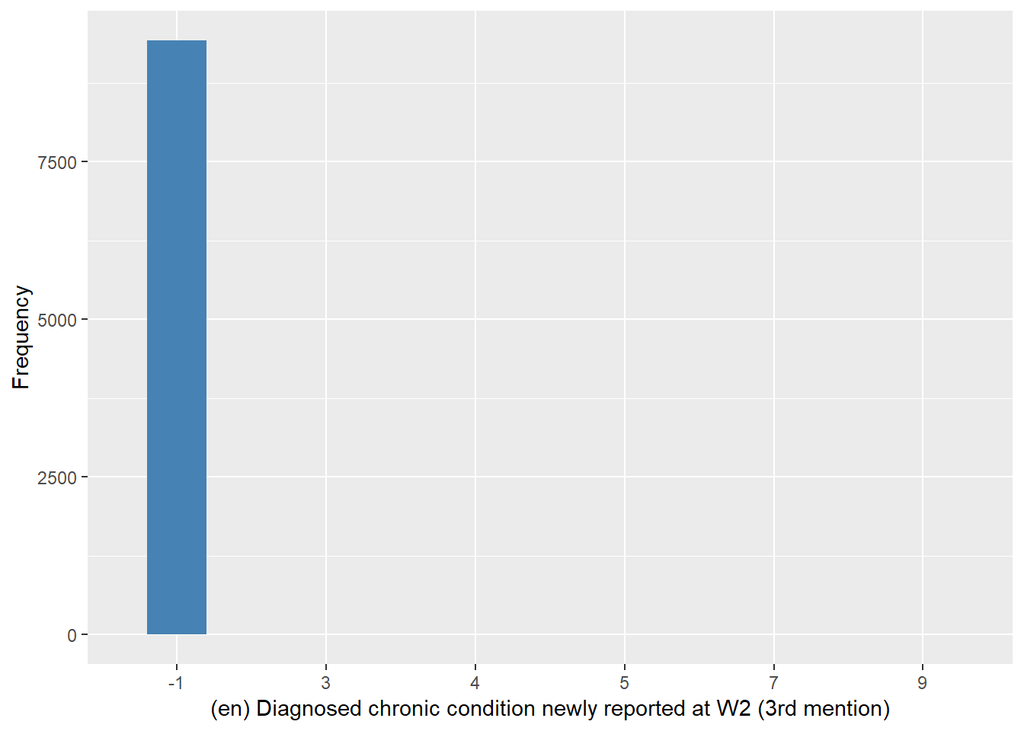

hedib04

| Sample size | Missing values |
| --- | --- |
| 9432 | 9428 |

Category

|  | 7 |
| --- | --- |
| Frequency | 4.00 |
| Percentage | 0.04 |

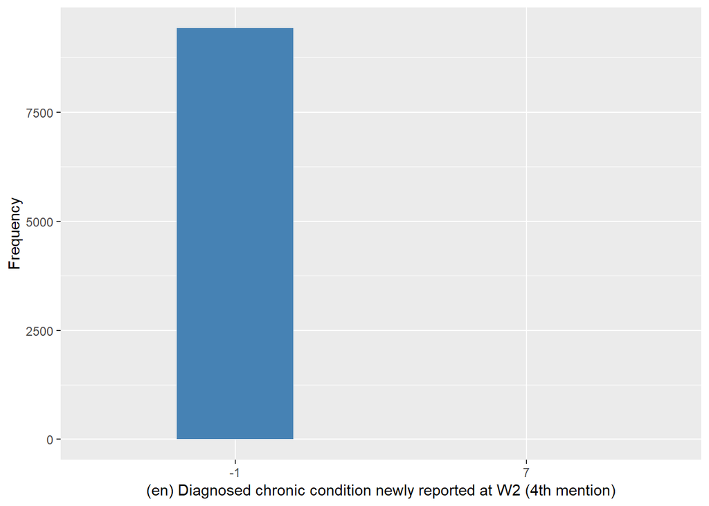

ybirth

| Sample size | Missing values |
| --- | --- |
| 9432 | 0 |

Summary

| Min. | 1st Qu. | Median | Mean | 3rd Qu. | Max. |
| --- | --- | --- | --- | --- | --- |
| 1908 | 1931 | 1939 | 1938 | 1947 | 1987 |

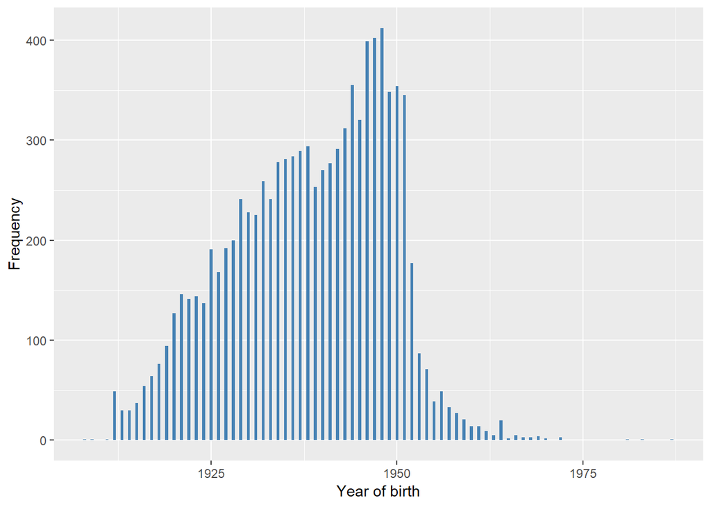

yintw (w1)

| Sample size | Missing values |
| --- | --- |
| 9432 | 108 |

Category

|  | 2002 | 2003 |
| --- | --- | --- |
| Frequency | 8220.00 | 1104.0 |
| Percentage | 87.15 | 11.7 |

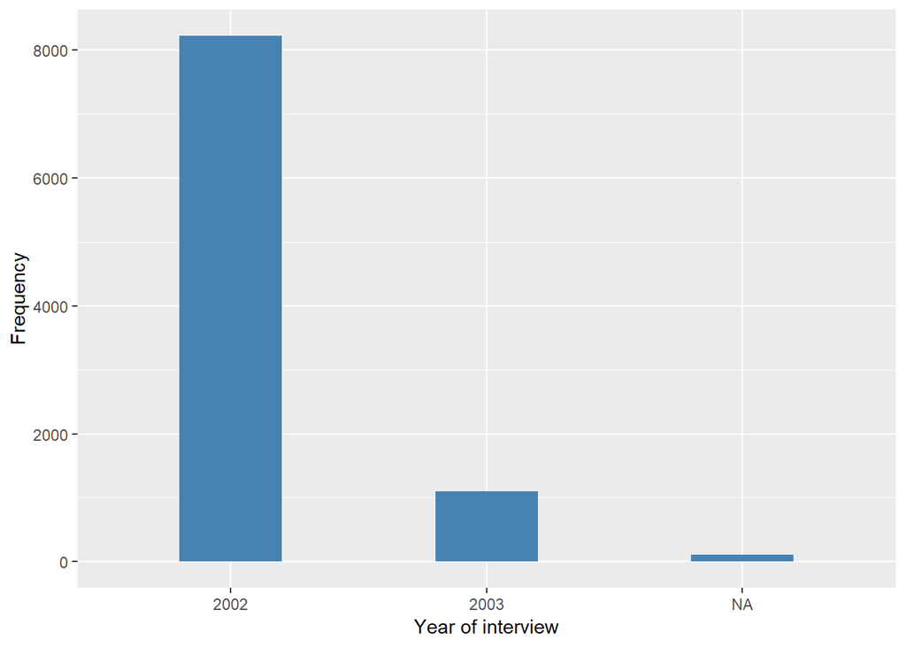

yintw (w2)

| Sample size | Missing values |
| --- | --- |
| 9432 | 0 |

Category

|  | 2004 | 2005 |
| --- | --- | --- |
| Frequency | 5240.00 | 4192.00 |
| Percentage | 55.56 | 44.44 |

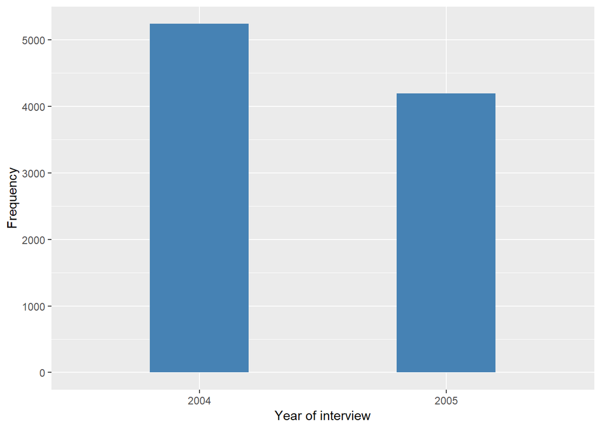

#### 2.1.2.2 Harmonisation algorithm

To compute `h_cpd` from the study-specific variable it has to be recoded as follows:

- `h_cpd w1 == 1 or some hedibX == 1 into 1`
- `h_cpd w1 != 1 and hedib01 == -9 into 997`
- `h_cpd w1 != 1 and hedib01 == -8 into 998`
- `otherwise into 0`

To compute `h_cpd_age` from the study-specific variable it has to be recoded as follows:

- `if h_cpd == 1 in w2 and 0 in w1, h_cpd_age = (year of interview w2-year of interview w1)/2+(year of interview w1 - ybirth)`
- `if h_cpd == 0, h_cpd_age = 996`
- `otherwise, h_cpd_age = 999`

**R script:**

```r
ELSA_w2 <- left_join(ELSA_w2, ELSA_ds, by = "id")

# Categorical variable harmonization
ELSA_ds_w2 <- tibble(id = ELSA_w2$id)
ELSA_ds_w2$h_cpd <- rep(0, length(ELSA_w2$id))
ELSA_ds_w2$h_cpd[which(ELSA_w2$h_cpd == 1 | ((ELSA_w2$hedib01 == 1 | ELSA_w2$hedib02 ==
    1 | ELSA_w2$hedib03 == 1 | ELSA_w2$hedib04 == 1)))] <- 1
ELSA_ds_w2$h_cpd[which((ELSA_w2$h_cpd != 1 | is.na(ELSA_w2$h_cpd)) & ELSA_w2$hedib01 ==
    -9)] <- 997
ELSA_ds_w2$h_cpd[which((ELSA_w2$h_cpd != 1 | is.na(ELSA_w2$h_cpd)) & ELSA_w2$hedib01 ==
    -8)] <- 998

# Continuous variable harmonization
ELSA_ds_w2$h_cpd_age <- rep(999, length(ELSA_w2$id))
ELSA_ds_w2$h_cpd_age[which(ELSA_ds_w2$h_cpd == 0)] <- 996
ELSA_ds_w2$h_cpd_age[which(ELSA_ds_w2$h_cpd == 1 & ELSA_w2$h_cpd == 0)] <- floor((ELSA_w2$yintw_w2[which(ELSA_ds_w2$h_cpd ==
    1 & ELSA_w2$h_cpd == 0)] + ELSA_w2$yintw_w1[which(ELSA_ds_w2$h_cpd == 1 &
    ELSA_w2$h_cpd == 0)])/2 - ELSA_w2$ybirth[which(ELSA_ds_w2$h_cpd == 1 & ELSA_w2$h_cpd ==
    0)])

# Update of global table
assign_merge <- function(endtib, sttib, log_vec = c(T), col_end_index = NULL,
    col_st_index = NULL) {
    newtib <- full_join(endtib, sttib, by = "id")
    row.names(newtib) <- newtib$id
    newtib[log_vec, col_end_index] <- newtib[log_vec, col_st_index]
    id_ind <- match("id", names(newtib))
    newtib <- newtib[, c(id_ind, col_end_index)]
    names(newtib)[2] <- "x"
    newtib$x <- car::recode(newtib$x, "NA=999")
    names(newtib)[2] <- names(endtib)[col_end_index]
    newtib
}
ELSA_ds_prov <- ELSA_ds[, c(1, 2)]
ELSA_ds_prov <- assign_merge(ELSA_ds_prov, ELSA_ds_w2, log_vec = ELSA_ds_w2$id,
    col_end_index = 2, col_st_index = 3)
ELSA_ds_aux <- ELSA_ds[, c(1, 3)]
ELSA_ds_aux <- assign_merge(ELSA_ds_aux, ELSA_ds_w2, log_vec = ELSA_ds_w2$id[which(ELSA_ds_w2$h_cpd !=
    999)], col_end_index = 2, col_st_index = 4)
ELSA_ds <- ELSA_ds_prov
ELSA_ds$h_cpd_age <- ELSA_ds_aux$h_cpd_age
rm(ELSA_ds_prov)
rm(ELSA_ds_aux)
```

#### 2.1.2.3 Statistics of the new harmonized variable

History of chronic pulmonary disorders

| Sample size | Missing values |
| --- | --- |
| 9432 | 5 |

Category

|  | 0 | 1 |
| --- | --- | --- |
| Frequency | 8738.00 | 689.0 |
| Percentage | 92.64 | 7.3 |

Type of missing

|  | 991 | 992 | 993 | 994 | 995 | 996 | 997 | 998 | 999 | NA |
| --- | --- | --- | --- | --- | --- | --- | --- | --- | --- | --- |
| Frequency | 0 | 0 | 0 | 0 | 0 | 0 | 1.00 | 4.00 | 0 | 0 |
| Percentage | 0 | 0 | 0 | 0 | 0 | 0 | 0.01 | 0.04 | 0 | 0 |

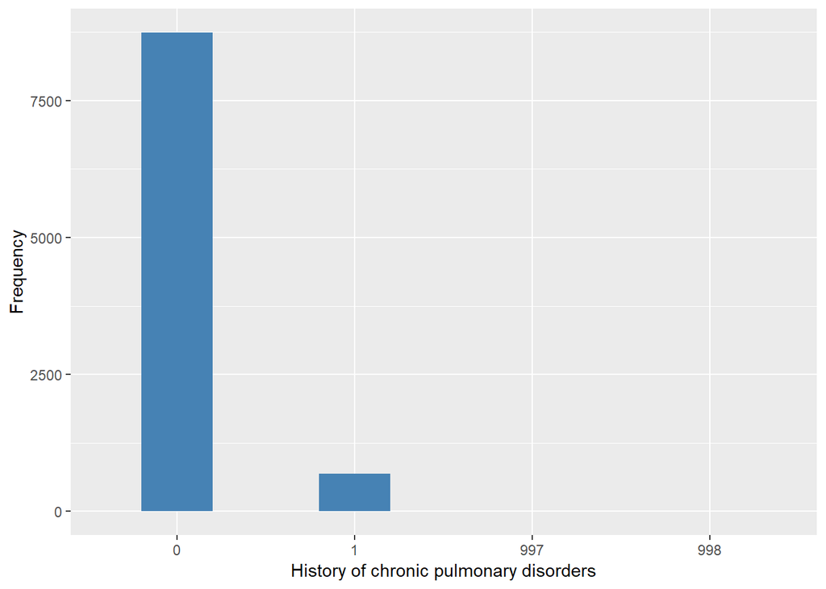

Age first diagnosed chronic pulmonary disease

| Sample size | Missing values |
| --- | --- |
| 9432 | 9295 |

Values

|  | No-missings | 991 | 992 | 993 | 994 | 995 | 996 | 997 | 998 | 999 | NA |
| --- | --- | --- | --- | --- | --- | --- | --- | --- | --- | --- | --- |
| Frequency | 137.00 | 0 | 0 | 0 | 0 | 0 | 8738.00 | 0 | 0 | 557.00 | 0 |
| Percentage | 1.45 | 0 | 0 | 0 | 0 | 0 | 92.64 | 0 | 0 | 5.91 | 0 |

Summary

| Min. | 1st Qu. | Median | Mean | 3rd Qu. | Max. |
| --- | --- | --- | --- | --- | --- |
| 42 | 58 | 68 | 67.8 | 76 | 91 |

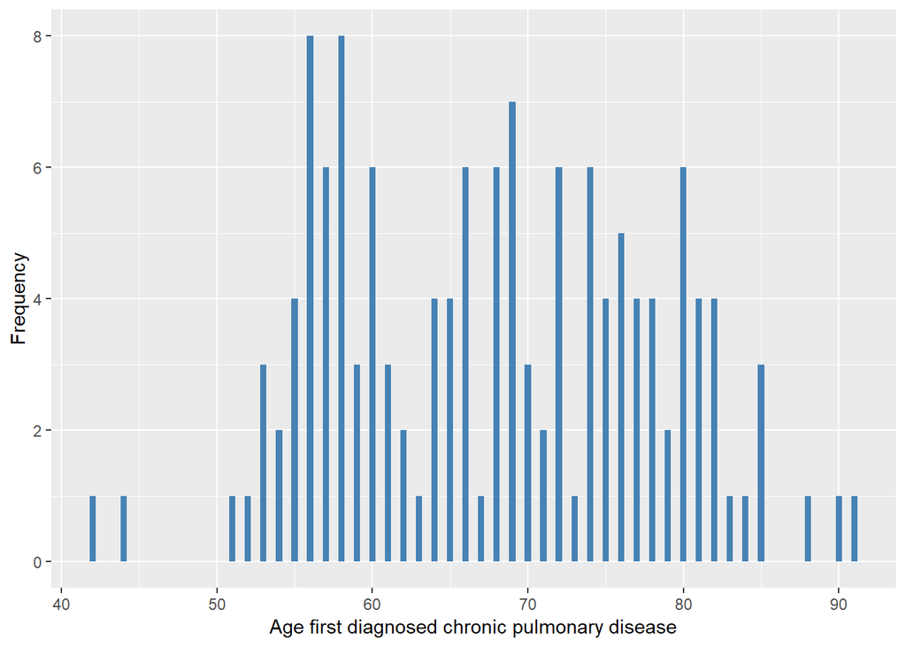

#### 2.1.2.4 Validation

|  | hedibX!=1->0 | hedibX==1->1 | hedibX==-9->997 | hedibX==-8->998 |
| --- | --- | --- | --- | --- |
| BeforeH | 8738 | 689 | 1 | 4 |
| AfterH | 8738 | 689 | 1 | 4 |

### 2.1.3 Wave 3

#### 2.1.3.1 Study-specific variable description

| **Name** | `dhediblu` | `ybirth` | `yintw (w2)` | `yintw (w3)` |
| --- | --- | --- | --- | --- |
| **Label** | `Chronic: lung disease diagnosis newly reported` | `year of birth` | `year of interview` | `year of interview` |
| **Table name** | `wave_3_elsa_data_v4` | `elsa_w3_hd` | `elsa_w2_hd` | `elsa_w3_hd` |
| **Categories** | `1 = Mentioned` `0 = Not mentioned` | `continuous` | `continuous` | `continuous` |
| **Missings** | `-9 = Refusal` `-8 = Don't know` `-1 = Not applicable` | `998 = Do not know` |  |  |
| **Description** |  |  |  |  |

dhediblu

| Sample size | Missing values |
| --- | --- |
| 9771 | 9 |

Category

|  | 0 | 1 |
| --- | --- | --- |
| Frequency | 9632.00 | 130.00 |
| Percentage | 98.58 | 1.33 |

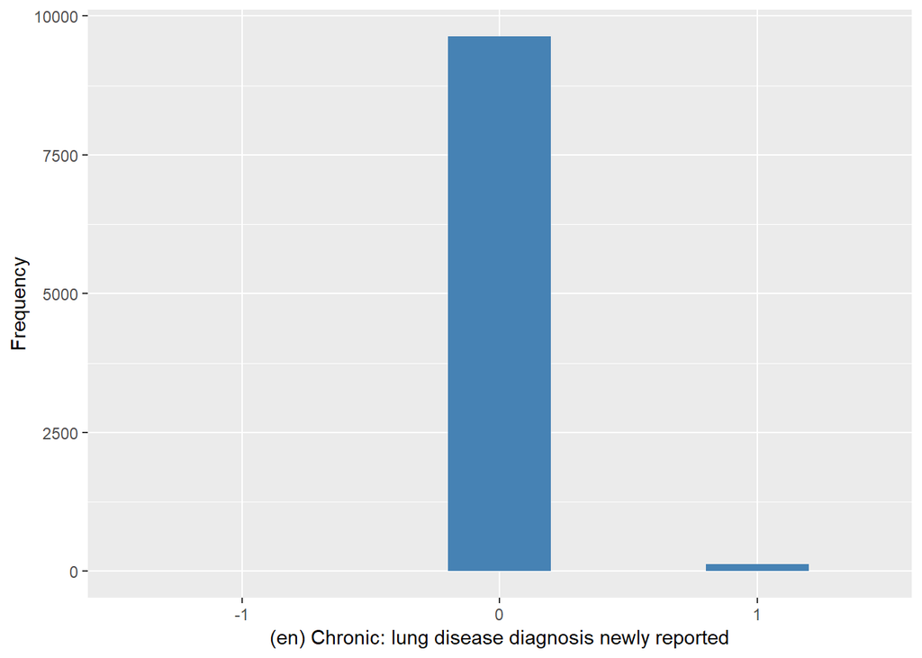

ybirth

| Sample size | Missing values |
| --- | --- |
| 9771 | 1 |

Summary

| Min. | 1st Qu. | Median | Mean | 3rd Qu. | Max. |
| --- | --- | --- | --- | --- | --- |
| 1908 | 1933 | 1943 | 1941 | 1950 | 1987 |

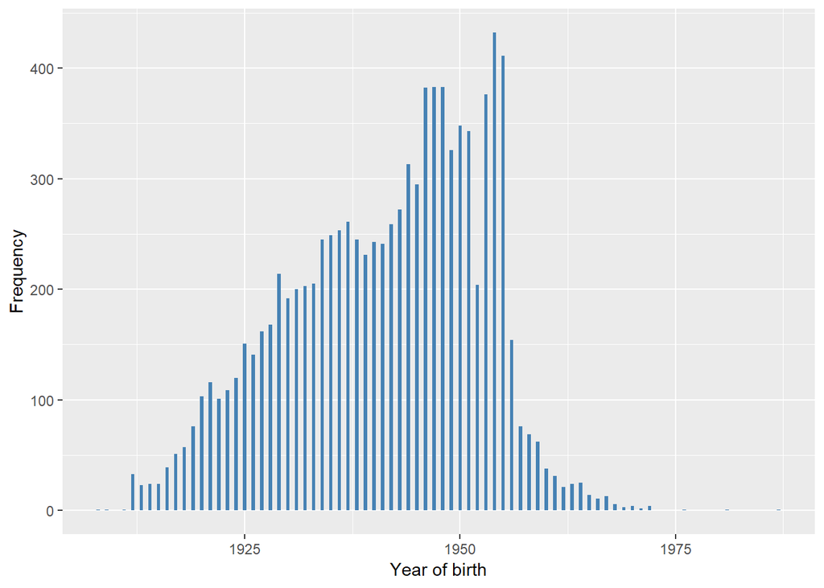

yintw (w2)

| Sample size | Missing values |
| --- | --- |
| 9771 | 2091 |

Category

|  | 2004 | 2005 |
| --- | --- | --- |
| Frequency | 4328.00 | 3352.00 |
| Percentage | 44.29 | 34.31 |

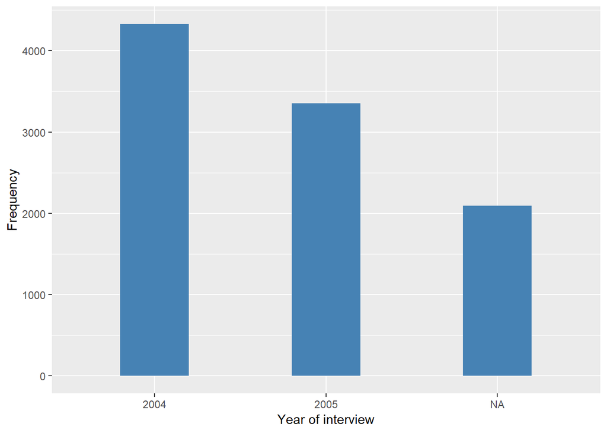

yintw (w3)

| Sample size | Missing values |
| --- | --- |
| 9771 | 0 |

Category

|  | 2006 | 2007 |
| --- | --- | --- |
| Frequency | 8099.00 | 1672.00 |
| Percentage | 82.89 | 17.11 |

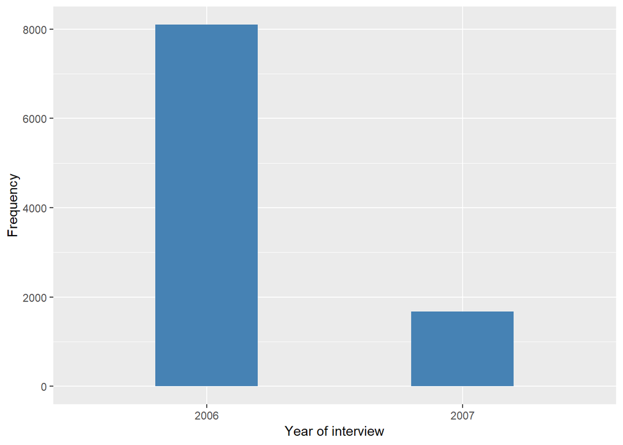

#### 2.1.3.2 Harmonisation algorithm

To compute `h_cpd` from the study-specific variable it has to be recoded as follows:

- `h_cpd previous == 1 or dhediblu == 1 into 1`
- `h_cpd previous == 0 and dhediblu == 0 into 0`
- `dhediblu == -1 into 996`
- `otherwise into 999`

To compute `h_cpd_age` from the study-specific variable it has to be recoded as follows:

- `if h_cpd == 1 in w3 and 0 in w2, h_cpd_age = (year of interview w3-year of interview w2)/2+(year of interview w2 - ybirth)`
- `if h_cpd == 0, h_cpd_age = 996`
- `otherwise, h_cpd_age = 999`

**R script:**

```r
ELSA_w3 <- left_join(ELSA_w3, ELSA_ds, by = "id")

# Categorical variable harmonization
ELSA_ds_w3 <- tibble(id = ELSA_w3$id)
ELSA_ds_w3$h_cpd <- rep(999, length(ELSA_w3$id))
ELSA_ds_w3$h_cpd[which((ELSA_w3$h_cpd != 1 | is.na(ELSA_w3$h_cpd)) & (ELSA_w3$dhediblu ==
    0))] <- 0
ELSA_ds_w3$h_cpd[which(ELSA_w3$h_cpd == 1 | (ELSA_w3$dhediblu == 1))] <- 1
ELSA_ds_w3$h_cpd[which((ELSA_w3$h_cpd != 1 | is.na(ELSA_w3$h_cpd)) & (ELSA_w3$dhediblu ==
    -1))] <- 996

ELSA_w3 <- left_join(ELSA_w3, ELSA_ds_w2, by = "id", suffix = c("", "_w2"))

# Continuous variable harmonization
ELSA_ds_w3$h_cpd_age <- rep(999, length(ELSA_w3$id))
ELSA_ds_w3$h_cpd_age[which(ELSA_ds_w3$h_cpd == 0)] <- 996
ELSA_ds_w3$h_cpd_age[which(ELSA_ds_w3$h_cpd == 1 & ELSA_w3$h_cpd_w2 == 0 & ELSA_w3$ybirth !=
    998)] <- floor((ELSA_w3$yintw_w2[which(ELSA_ds_w3$h_cpd == 1 & ELSA_w3$h_cpd_w2 ==
    0 & ELSA_w3$ybirth != 998)] + ELSA_w3$yintw_w3[which(ELSA_ds_w3$h_cpd ==
    1 & ELSA_w3$h_cpd_w2 == 0 & ELSA_w3$ybirth != 998)])/2 - ELSA_w3$ybirth[which(ELSA_ds_w3$h_cpd ==
    1 & ELSA_w3$h_cpd_w2 == 0 & ELSA_w3$ybirth != 998)])
ELSA_ds_w3$h_cpd_age[which(ELSA_ds_w3$h_cpd == 1 & !is.na(ELSA_w3$h_cpd_age) &
    !ELSA_w3$h_cpd_age %in% miss_values_vector)] <- ELSA_w3$h_cpd_age[which(ELSA_ds_w3$h_cpd ==
    1 & !is.na(ELSA_w3$h_cpd_age) & !ELSA_w3$h_cpd_age %in% miss_values_vector)]

# Update of global table
assign_merge <- function(endtib, sttib, log_vec = c(T), col_end_index = NULL,
    col_st_index = NULL) {
    newtib <- full_join(endtib, sttib, by = "id")
    row.names(newtib) <- newtib$id
    newtib[log_vec, col_end_index] <- newtib[log_vec, col_st_index]
    id_ind <- match("id", names(newtib))
    newtib <- newtib[, c(id_ind, col_end_index)]
    names(newtib)[2] <- "x"
    newtib$x <- car::recode(newtib$x, "NA=999")
    names(newtib)[2] <- names(endtib)[col_end_index]
    newtib
}
ELSA_ds_prov <- ELSA_ds[, c(1, 2)]
ELSA_ds_prov <- assign_merge(ELSA_ds_prov, ELSA_ds_w3, log_vec = ELSA_ds_w3$id,
    col_end_index = 2, col_st_index = 3)
ELSA_ds_aux <- ELSA_ds[, c(1, 3)]
ELSA_ds_aux <- assign_merge(ELSA_ds_aux, ELSA_ds_w3, log_vec = ELSA_ds_w3$id[which(ELSA_ds_w3$h_cpd !=
    999)], col_end_index = 2, col_st_index = 4)
ELSA_ds <- ELSA_ds_prov
ELSA_ds$h_cpd_age <- ELSA_ds_aux$h_cpd_age
rm(ELSA_ds_prov)
rm(ELSA_ds_aux)
```

#### 2.1.3.3 Statistics of the new harmonized variable

History of chronic pulmonary disorders

| Sample size | Missing values |
| --- | --- |
| 9771 | 8 |

Category

|  | 0 | 1 |
| --- | --- | --- |
| Frequency | 9105.00 | 658.00 |
| Percentage | 93.18 | 6.73 |

Type of missing

|  | 991 | 992 | 993 | 994 | 995 | 996 | 997 | 998 | 999 | NA |
| --- | --- | --- | --- | --- | --- | --- | --- | --- | --- | --- |
| Frequency | 0 | 0 | 0 | 0 | 0 | 8.00 | 0 | 0 | 0 | 0 |
| Percentage | 0 | 0 | 0 | 0 | 0 | 0.08 | 0 | 0 | 0 | 0 |

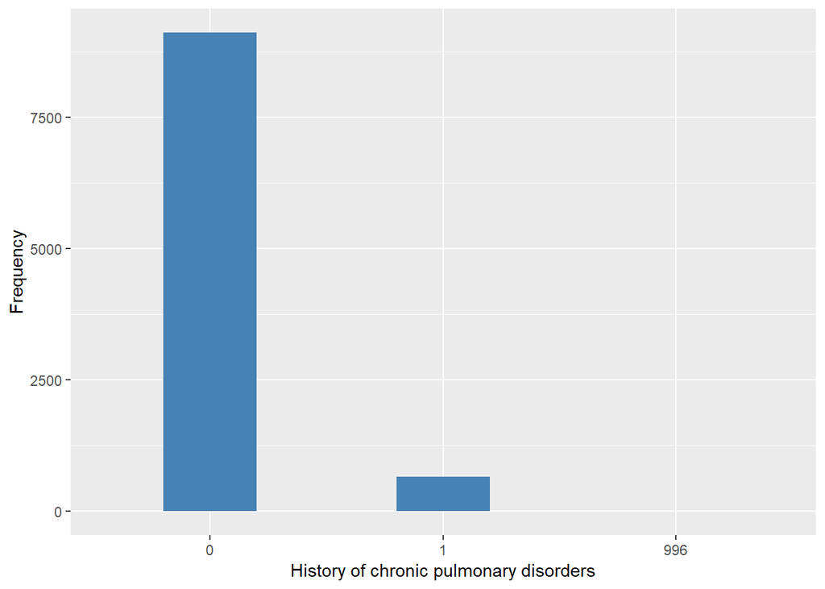

Age first diagnosed chronic pulmonary disease

| Sample size | Missing values |
| --- | --- |
| 9771 | 9596 |

Values

|  | No-missings | 991 | 992 | 993 | 994 | 995 | 996 | 997 | 998 | 999 | NA |
| --- | --- | --- | --- | --- | --- | --- | --- | --- | --- | --- | --- |
| Frequency | 175.00 | 0 | 0 | 0 | 0 | 0 | 9105.00 | 0 | 0 | 491.00 | 0 |
| Percentage | 1.79 | 0 | 0 | 0 | 0 | 0 | 93.18 | 0 | 0 | 5.03 | 0 |

Summary

| Min. | 1st Qu. | Median | Mean | 3rd Qu. | Max. |
| --- | --- | --- | --- | --- | --- |
| 42 | 60 | 68 | 67.79 | 74.5 | 90 |

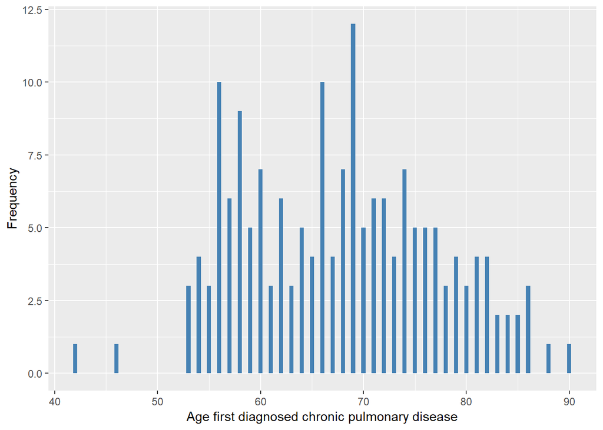

#### 2.1.3.4 Validation

|  | dhediblu==0->0 | dhediblu==1->1 | dhediblu==-1->996 |
| --- | --- | --- | --- |
| BeforeH | 9105 | 658 | 8 |
| AfterH | 9105 | 658 | 8 |

### 2.1.4 Wave 4

#### 2.1.4.1 Study-specific variable description

| **Name** | `hediblu` | `ybirth` | `yintw (w3)` | `yintw (w4)` |
| --- | --- | --- | --- | --- |
| **Label** | `Chronic: lung disease diagnosis newly reported` | `year of birth` | `year of interview` | `year of interview` |
| **Table name** | `wave_4_elsa_data_v3` | `elsa_w4_hd` | `elsa_w3_hd` | `elsa_w4_hd` |
| **Categories** | `1 = Mentioned` `0 = Not mentioned` | `continuous` | `continuous` | `continuous` |
| **Missings** | `-9 = Refusal` `-8 = Don't know` `-1 = Not applicable` |  |  |  |
| **Description** |  |  |  |  |

hediblu

| Sample size | Missing values |
| --- | --- |
| 11050 | 18 |

Category

|  | 0 | 1 |
| --- | --- | --- |
| Frequency | 10788.00 | 244.00 |
| Percentage | 97.63 | 2.21 |

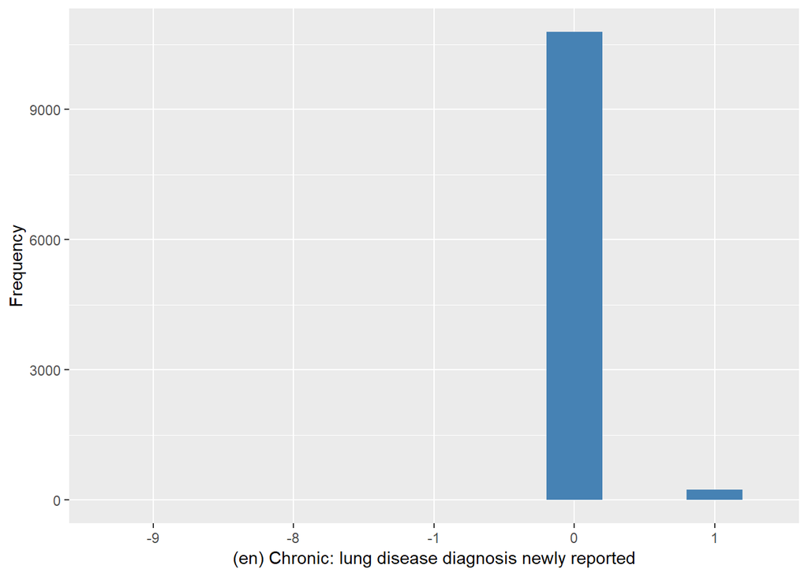

ybirth

| Sample size | Missing values |
| --- | --- |
| 11050 | 0 |

Summary

| Min. | 1st Qu. | Median | Mean | 3rd Qu. | Max. |
| --- | --- | --- | --- | --- | --- |
| 1908 | 1936 | 1944 | 1943 | 1951 | 1984 |

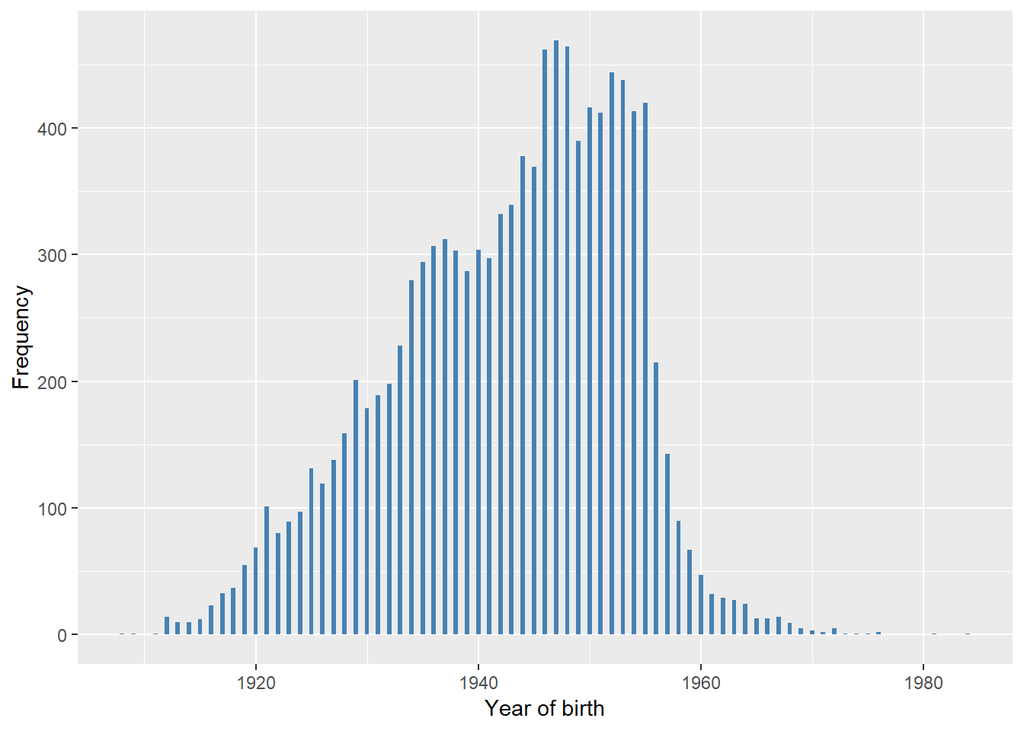

yintw (w4)

| Sample size | Missing values |
| --- | --- |
| 11050 | 0 |

Category

|  | 2008 | 2009 |
| --- | --- | --- |
| Frequency | 7127.0 | 3923.0 |
| Percentage | 64.5 | 35.5 |

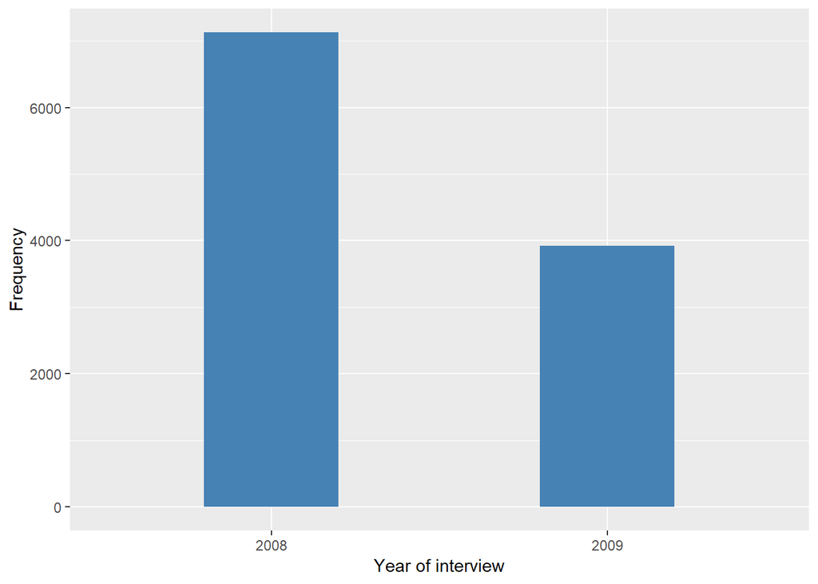

yintw (w3)

| Sample size | Missing values |
| --- | --- |
| 11050 | 3142 |

Category

|  | 2006 | 2007 |
| --- | --- | --- |
| Frequency | 6653.00 | 1255.00 |
| Percentage | 60.21 | 11.36 |

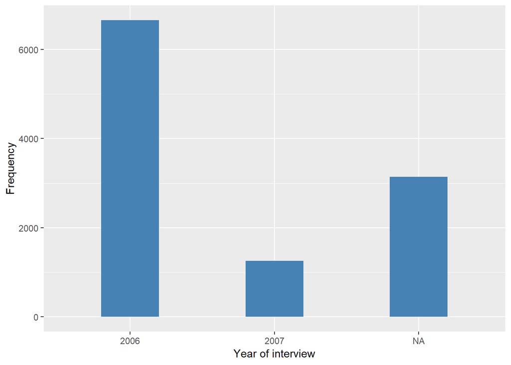

#### 2.1.4.2 Harmonisation algorithm

To compute `h_cpd` from the study-specific variable it has to be recoded as follows:

- `h_cpd previous == 1 or hediblu == 1 into 1`
- `h_cpd previous == 0 and hediblu == 0 into 0`
- `hediblu == -1 into 996`
- `hediblu == -9 into 997`
- `hediblu == -8 into 998`
- `otherwise into 999`

To compute `h_cpd_age` from the study-specific variable it has to be recoded as follows:

- `if h_cpd == 1 in w4 and 0 in w3, h_cpd_age = (year of interview w4-year of interview w3)/2+(year of interview w3 - ybirth)`
- `if h_cpd == 0, h_cpd_age = 996`
- `otherwise, h_cpd_age = 999`

**R script:**

```r
ELSA_w4 <- left_join(ELSA_w4, ELSA_ds, by = "id")

# Categorical variable harmonization
ELSA_ds_w4 <- tibble(id = ELSA_w4$id)
ELSA_ds_w4$h_cpd <- rep(999, length(ELSA_w4$id))
ELSA_ds_w4$h_cpd[which((ELSA_w4$h_cpd != 1 | is.na(ELSA_w4$h_cpd)) & (ELSA_w4$hediblu ==
    0))] <- 0
ELSA_ds_w4$h_cpd[which(ELSA_w4$h_cpd == 1 | (ELSA_w4$hediblu == 1))] <- 1
ELSA_ds_w4$h_cpd[which((ELSA_w4$h_cpd != 1 | is.na(ELSA_w4$h_cpd)) & ELSA_w4$hediblu ==
    -1)] <- 996
ELSA_ds_w4$h_cpd[which((ELSA_w4$h_cpd != 1 | is.na(ELSA_w4$h_cpd)) & ELSA_w4$hediblu ==
    -9)] <- 997
ELSA_ds_w4$h_cpd[which((ELSA_w4$h_cpd != 1 | is.na(ELSA_w4$h_cpd)) & ELSA_w4$hediblu ==
    -8)] <- 998

ELSA_w4 <- left_join(ELSA_w4, ELSA_ds_w3, by = "id", suffix = c("", "_w3"))

# Continuous variable harmonization
ELSA_ds_w4$h_cpd_age <- rep(999, length(ELSA_w4$id))
ELSA_ds_w4$h_cpd_age[which(ELSA_ds_w4$h_cpd == 0)] <- 996
ELSA_ds_w4$h_cpd_age[which(ELSA_ds_w4$h_cpd == 1 & ELSA_w4$h_cpd_w3 == 0)] <- floor((ELSA_w4$yintw_w3[which(ELSA_ds_w4$h_cpd ==
    1 & ELSA_w4$h_cpd_w3 == 0)] + ELSA_w4$yintw_w4[which(ELSA_ds_w4$h_cpd ==
    1 & ELSA_w4$h_cpd_w3 == 0)])/2 - ELSA_w4$ybirth[which(ELSA_ds_w4$h_cpd ==
    1 & ELSA_w4$h_cpd_w3 == 0)])
ELSA_ds_w4$h_cpd_age[which(ELSA_ds_w4$h_cpd == 1 & !is.na(ELSA_w4$h_cpd_age) &
    !ELSA_w4$h_cpd_age %in% miss_values_vector)] <- ELSA_w4$h_cpd_age[which(ELSA_ds_w4$h_cpd ==
    1 & !is.na(ELSA_w4$h_cpd_age) & !ELSA_w4$h_cpd_age %in% miss_values_vector)]

# Update of global table
assign_merge <- function(endtib, sttib, log_vec = c(T), col_end_index = NULL,
    col_st_index = NULL) {
    newtib <- full_join(endtib, sttib, by = "id")
    row.names(newtib) <- newtib$id
    newtib[log_vec, col_end_index] <- newtib[log_vec, col_st_index]
    id_ind <- match("id", names(newtib))
    newtib <- newtib[, c(id_ind, col_end_index)]
    names(newtib)[2] <- "x"
    newtib$x <- car::recode(newtib$x, "NA=999")
    names(newtib)[2] <- names(endtib)[col_end_index]
    newtib
}
ELSA_ds_prov <- ELSA_ds[, c(1, 2)]
ELSA_ds_prov <- assign_merge(ELSA_ds_prov, ELSA_ds_w4, log_vec = ELSA_ds_w4$id,
    col_end_index = 2, col_st_index = 3)
ELSA_ds_aux <- ELSA_ds[, c(1, 3)]
ELSA_ds_aux <- assign_merge(ELSA_ds_aux, ELSA_ds_w4, log_vec = ELSA_ds_w4$id[which(ELSA_ds_w4$h_cpd !=
    999)], col_end_index = 2, col_st_index = 4)
ELSA_ds <- ELSA_ds_prov
ELSA_ds$h_cpd_age <- ELSA_ds_aux$h_cpd_age
rm(ELSA_ds_prov)
rm(ELSA_ds_aux)
```

#### 2.1.4.3 Statistics of the new harmonized variable

History of chronic pulmonary disorders

| Sample size | Missing values |
| --- | --- |
| 11050 | 15 |

Category

|  | 0 | 1 |
| --- | --- | --- |
| Frequency | 10309.00 | 726.00 |
| Percentage | 93.29 | 6.57 |

Type of missing

|  | 991 | 992 | 993 | 994 | 995 | 996 | 997 | 998 | 999 | NA |
| --- | --- | --- | --- | --- | --- | --- | --- | --- | --- | --- |
| Frequency | 0 | 0 | 0 | 0 | 0 | 0 | 5.00 | 10.00 | 0 | 0 |
| Percentage | 0 | 0 | 0 | 0 | 0 | 0 | 0.05 | 0.09 | 0 | 0 |

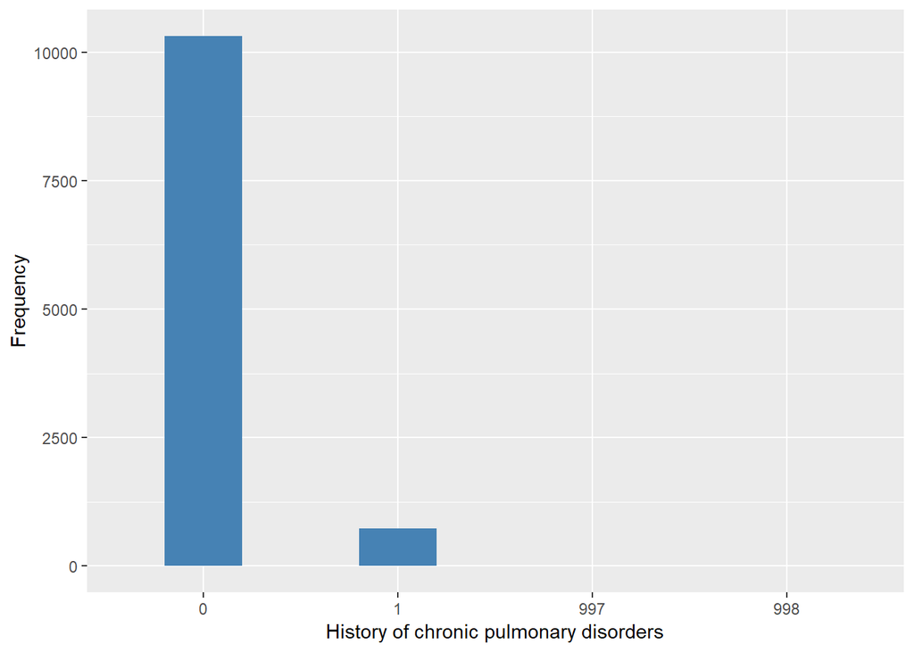

Age first diagnosed chronic pulmonary disease

| Sample size | Missing values |
| --- | --- |
| 11050 | 10835 |

Values

|  | No-missings | 991 | 992 | 993 | 994 | 995 | 996 | 997 | 998 | 999 | NA |
| --- | --- | --- | --- | --- | --- | --- | --- | --- | --- | --- | --- |
| Frequency | 215.00 | 0 | 0 | 0 | 0 | 0 | 10309.00 | 0 | 0 | 526.00 | 0 |
| Percentage | 1.95 | 0 | 0 | 0 | 0 | 0 | 93.29 | 0 | 0 | 4.76 | 0 |

Summary

| Min. | 1st Qu. | Median | Mean | 3rd Qu. | Max. |
| --- | --- | --- | --- | --- | --- |
| 42 | 59 | 66 | 66.6 | 74 | 90 |

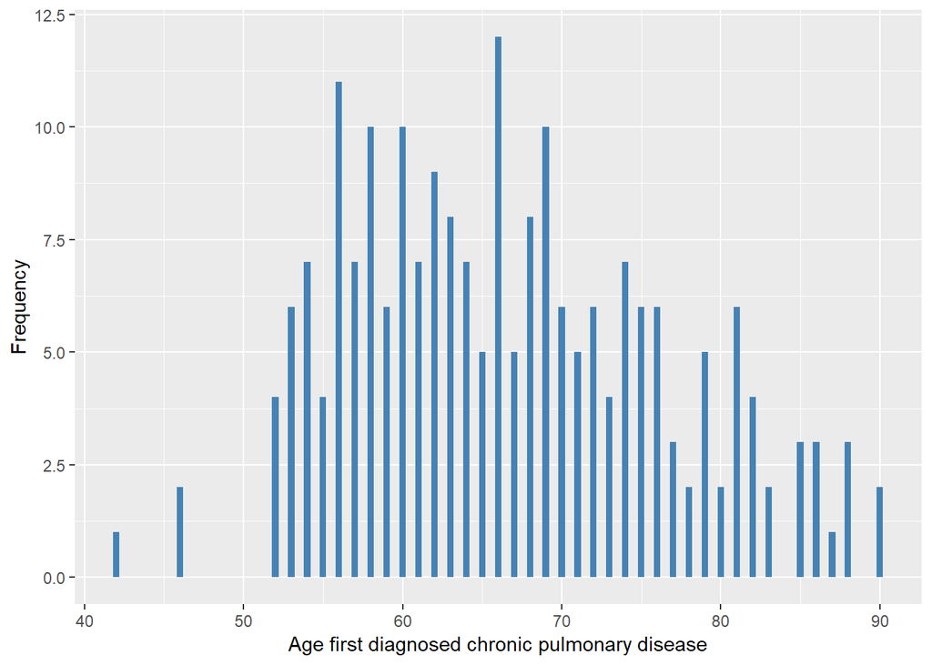

#### 2.1.4.4 Validation

|  | hediblu==0->0 | hediblu==1->1 | hediblu==-9->997 | hediblu==-8->998 |
| --- | --- | --- | --- | --- |
| BeforeH | 10309 | 726 | 5 | 10 |
| AfterH | 10309 | 726 | 5 | 10 |

### 2.1.5 Wave 5

#### 2.1.5.1 Study-specific variable description

| **Name** | `hediblu` | `ybirth` | `yintw (w4)` | `yintw (w5)` |
| --- | --- | --- | --- | --- |
| **Label** | `Chronic: lung disease diagnosis newly reported` | `year of birth` | `year of interview` | `year of interview` |
| **Table name** | `wave_5_elsa_data_v4` | `elsa_w5_hd` | `elsa_w4_hd` | `elsa_w5_hd` |
| **Categories** | `1 = Mentioned` `0 = Not mentioned` | `continuous` | `continuous` | `continuous` |
| **Missings** | `-9 = Refusal` `-8 = Don't know` `-1 = Not applicable` |  |  |  |
| **Description** |  |  |  |  |

hediblu

| Sample size | Missing values |
| --- | --- |
| 10274 | 15 |

Category

|  | 0 | 1 |
| --- | --- | --- |
| Frequency | 10118.00 | 141.00 |
| Percentage | 98.48 | 1.37 |

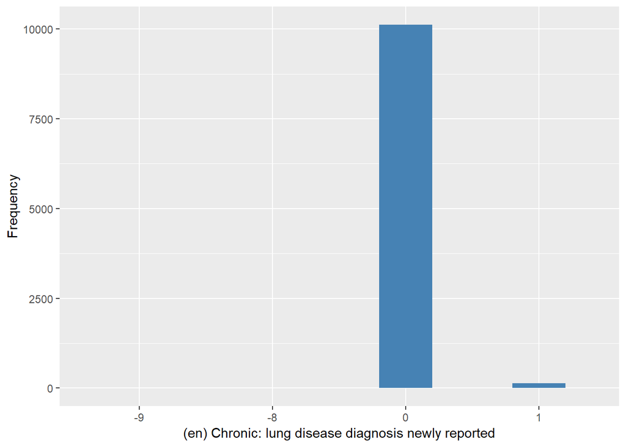

ybirth

| Sample size | Missing values |
| --- | --- |
| 10274 | 0 |

Summary

| Min. | 1st Qu. | Median | Mean | 3rd Qu. | Max. |
| --- | --- | --- | --- | --- | --- |
| 1908 | 1936 | 1945 | 1943 | 1951 | 1984 |

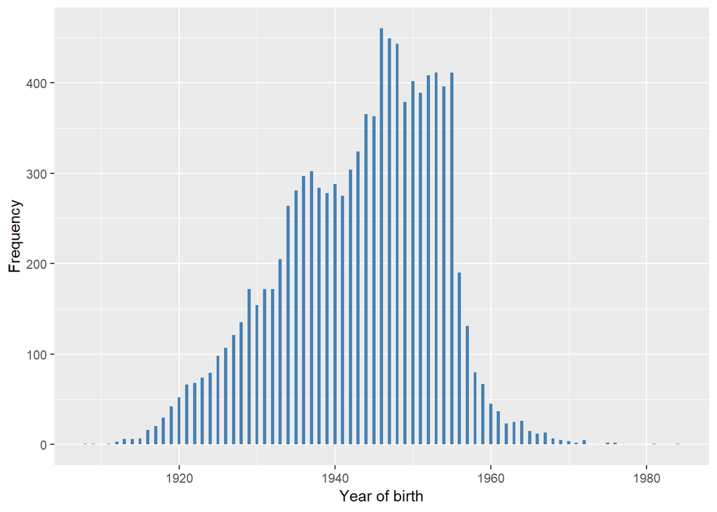

yintw (w4)

| Sample size | Missing values |
| --- | --- |
| 10274 | 814 |

Category

|  | 2008 | 2009 |
| --- | --- | --- |
| Frequency | 6181.00 | 3279.00 |
| Percentage | 60.16 | 31.92 |

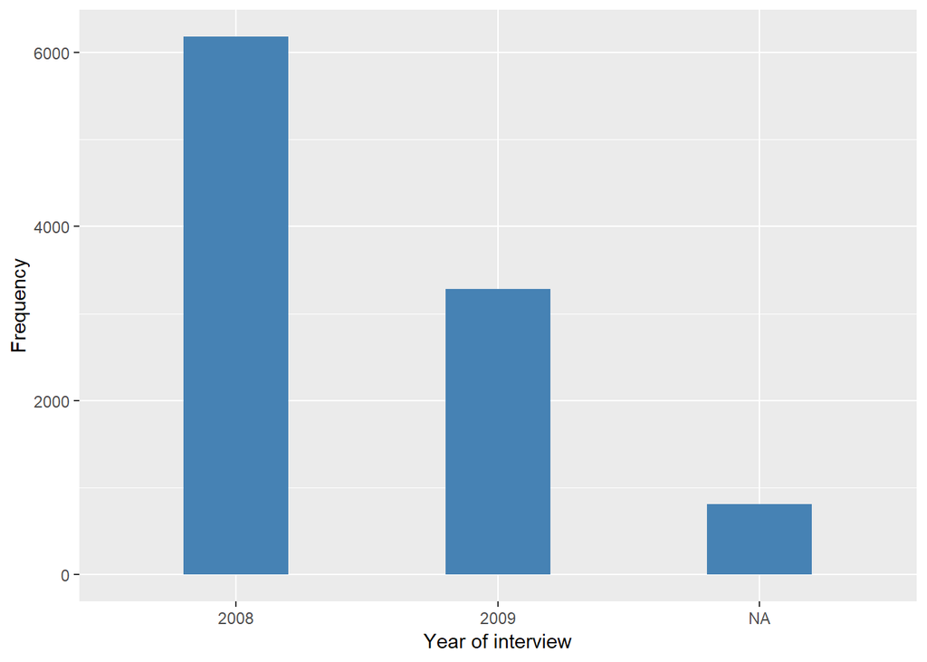

yintw (w5)

| Sample size | Missing values |
| --- | --- |
| 10274 | 0 |

Category

|  | 2010 | 2011 |
| --- | --- | --- |
| Frequency | 7066.00 | 3208.00 |
| Percentage | 68.78 | 31.22 |

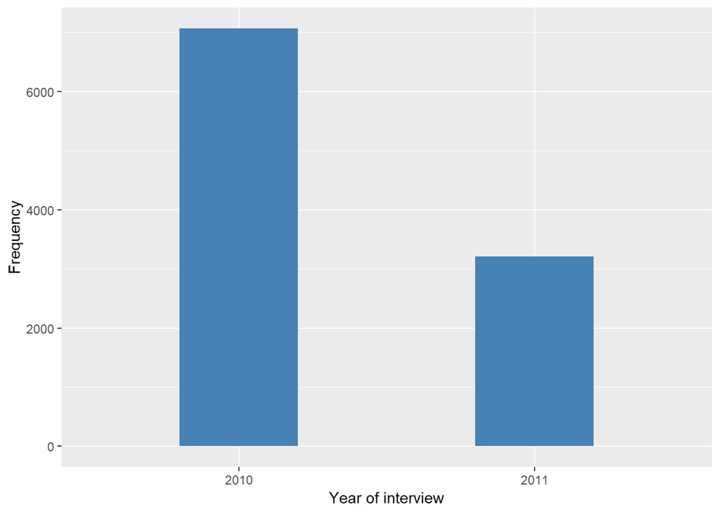